# Do MLLMs show effects of Embodied Simulation

Anonymous

10/10/2019

# 1 Setup

## 1.1 Libraries

```r
library(extrafont)
library(tidyverse)
library(stringr)
library(ggtext)
library(xtable)
library(lmerTest)
library(MuMIn)
```

## 1.2 Parameters

```r
colors.match <- "#1C73C2CC"
colors.mismatch <- "#D32F2FCC"
colors.llm <- "#66cc22cc"
colors.ib <- "#cc2266cc"
colors.human <- "#222222cc"
```

## 1.3 Functions

```r
load_data <- function(models, datasets, metric, data_types) {

  fnames <- c()

  for (dataset in datasets) {
    for (model in models) {

      dataset_safe <- str_replace(dataset, "/", "_")

      fp <- paste0(
        "../results/", dataset, "/", dataset_safe, "_", model, "_",
        metric, "_", data_types, ".csv")
      fnames <- c(fnames, fp)
    }
  }

  data <- do.call(rbind,lapply(fnames,read.csv)) %>%
    mutate(
      model = factor(model, levels=models),
      dataset = case_match(dataset,
        "connell2007" ~ "Color",
        "pecher2006" ~ "Shape",
        "muraki2021" ~ "Orientation",
        "winter2012/e1" ~ "Size",
        "winter2012/e2" ~ "Volume"
      ),
      dataset = factor(dataset, levels=c("Shape", "Color", "Orientation", "Size", "Volume")),
      item_id = case_when(
        # Deal w/ Shape/LM item stims
        item_type == "prepositional" ~ paste("EXPL", item, sep="_"),
        item_type == "landmark" ~ paste("LM", item, sep="_"),
        TRUE ~ as.character(item),
      ),
      quadruplet_id = paste(dataset, item_id, sep="_"),
      item_id = paste(dataset, item_id, sent_condition, media_condition, sep="_")
    )

  return(data)
}
```

```r
get_max_min <- function(df) {
  df_summary <- df %>%
    group_by(
      model, dataset, match
    ) %>%
    summarize(
      mean_cl_boot(similarity),
      .groups="drop"
    ) %>%
    summarize(
      ymin = min(ymin),
      ymax = max(ymax)
    )

  return(
      list(
      "ymin" = df_summary %>% pull(ymin),
      "ymax" = df_summary %>% pull(ymax)
    )
  )
}
```

## 1.4 Load human data

### 1.4.1 Zwaan & Pecher data

```r
# ZP 2012
zp = rbind(
  read.csv("../data/pecher2012/human_data/Experiment_1a.csv") %>%
    mutate(dataset="Orientation", experiment="ZP1A"),
  read.csv("../data/pecher2012/human_data/Experiment_1b.csv") %>%
    mutate(dataset="Orientation", experiment="ZP1B"),
  read.csv("../data/pecher2012/human_data/Experiment_2a.csv") %>%
    mutate(dataset="Shape", experiment="ZP2A"),
  read.csv("../data/pecher2012/human_data/Experiment_2b.csv") %>%
    mutate(dataset="Shape", experiment="ZP2B")
) %>%
  mutate(
    rt = rt * 1000 # convert to ms
  ) %>%
  select(
    ppt_id, item, media_condition, sent_condition, match, accuracy, rt, dataset, experiment
  )
```

### 1.4.2 Winter & Bergen E1

```r
wb1 <- read.csv("../data/winter2012/e1/human_data.csv") %>%
  filter(
    CRITICAL == "CRITICAL"
  ) %>%
  separate(
    CONDITION, c("sentence_type", "image_type")
  ) %>%
  mutate(
    item_type = ifelse(is.na(LM), "EXPL", "LM"),
    match = recode(SAME, "SAME"="match", "DIFF"="mismatch"),
    item_id = paste(item_type, ITEM, sep="_"),
    media_condition = ifelse(image_type == "BIG", "a", "b"),
    sent_condition = ifelse(sentence_type == "NEAR", "a", "b"),
    dataset = "Size",
    experiment = "WB1"
  ) %>%
  rename(
    ppt_id = Subject,
    block = Block,
    item = item_id,
    accuracy = Pic.ACC,
    rt = Pic.RT
  ) %>%
  select(
    ppt_id, item, media_condition, sent_condition, match, accuracy, rt, dataset, experiment
  )
```

### 1.4.3 Winter & Bergen e2

```r
wb2.raw <- read.csv("../data/winter2012/e2/human_data.csv")

# Exclude low-acc ppts
wb2.ppt.ex.acc <- wb2.raw %>%
  group_by(Subject) %>%
  summarize(acc = mean(SoundOut1.ACC)) %>%
  arrange(acc) %>%
  filter(acc < 0.8) %>%
  pull(Subject)


wb2 <- wb2.raw %>%
  filter(
    Type == "CRITICAL",
    !Subject %in% wb2.ppt.ex.acc,
    FirstLanguage %in% c("English", "english")
  ) %>%
  separate(
    CONDITION, c("sentence_type", "sound_type")
  ) %>%
  mutate(
    match = recode(SAME, "SAME"="match", "DIFF"="mismatch"),
    media_condition = ifelse(sound_type == "LOUD", "a", "b"),
    sent_condition = ifelse(sentence_type == "NEAR", "a", "b"),
    dataset = "Volume",
    experiment = "WB2"
  ) %>%
  rename(
    ppt_id = Subject,
    block = Block,
    item = ITEM,
    accuracy = SoundOut1.ACC,
    rt = SoundOut1.RT
  ) %>%
  select(
    ppt_id, item, media_condition, sent_condition, match, accuracy, rt, dataset, experiment
  )
```

### 1.4.4 Combine human data & filter RT

```r
human_data <- rbind(zp, wb1, wb2) %>%
  mutate(
    dataset = factor(
      dataset,
      levels=c("Shape", "Color", "Orientation", "Size", "Volume")
    ),
    quadruplet_id = paste(dataset, item, sep="_"),
    item_id = paste(
      dataset, item, sent_condition, media_condition,
      sep="_"),
    ppt_id = paste(experiment, ppt_id, sep="_")
  )  %>%
  filter(
    rt > 300,
    rt < 3000
  )
```

# 2 H1: Does imagebind show match/no-match effect for sentences/images?

```r
datasets <- c("connell2007", "pecher2006", "muraki2021", "winter2012/e1", "winter2012/e2")
models <- c("imagebind")
metric = "cosine"
data_types <- "sentence_media"

h1.data <- load_data(models, datasets, metric, data_types)
```

## 2.1 H1A: Aggregate Test

Significant effect of match vs non-match overall.

```r
# Run linear model
h1.agg <- summary(lmer(similarity ~ match + (1 | quadruplet_id) +
                         (1 | dataset), data = h1.data))

summary(h1.agg)
```

```
## Linear mixed model fit by REML. t-tests use Satterthwaite's method [
## lmerModLmerTest]
## Formula: similarity ~ match + (1 | quadruplet_id) + (1 | dataset)
##    Data: h1.data
##
## REML criterion at convergence: -1857.7
##
## Scaled residuals:
##     Min      1Q  Median      3Q     Max
## -3.4324 -0.4696  0.0148  0.4725  3.6715
##
## Random effects:
##  Groups        Name        Variance  Std.Dev.
##  quadruplet_id (Intercept) 0.0025537 0.05053
##  dataset       (Intercept) 0.0005159 0.02271
##  Residual                  0.0016122 0.04015
## Number of obs: 608, groups:  quadruplet_id, 152; dataset, 5
##
## Fixed effects:
##                 Estimate Std. Error         df t value Pr(>|t|)
## (Intercept)     0.209852   0.011401   4.162430  18.407 3.81e-05 ***
## matchmismatch  -0.010630   0.003257 455.000043  -3.264  0.00118 **
## ---
## Signif. codes:  0 '***' 0.001 '**' 0.01 '*' 0.05 '.' 0.1 ' ' 1
##
## Correlation of Fixed Effects:
##             (Intr)
## matchmsmtch -0.143
```

## 2.2 H1B-C: By Feature type

Significant effects for color & shape, but not orientation, size, & volume.

```r
# Initialize empty data frame to store summarized results
h1.summary <- data.frame()

# Loop through each unique combination of model and dataset
for (dataset_name in unique(h1.data$dataset)) {

  # Subset the data
  subset_data <- h1.data %>%
    filter(dataset == dataset_name)


  # Run linear model
  result <- summary(lmer(similarity ~ match + (1 | quadruplet_id),
                         data = subset_data))

  # Store the summarized t-test result in the data frame
  h1.summary <- rbind(h1.summary, data.frame(
    dataset = dataset_name,
    estimate = result$coefficients[2,1],
    df = result$coefficients[2,3],
    t_value = result$coefficients[2,4],
    p_value = result$coefficients[2,5]
  ))
}

# View the summarized results
h1.summary <- h1.summary %>%
  mutate(
    dataset = factor(dataset, levels=c("Shape", "Color", "Orientation", "Size", "Volume")),
    signif_star = case_when(
      p_value < 0.001 ~ "***",
      p_value < 0.01 ~ "**",
      p_value < 0.05 ~ "*",
      TRUE ~ ""
    )
  )

h1.summary
```

```
##       dataset     estimate  df    t_value      p_value signif_star
## 1       Color -0.010793449  35 -2.1629575 0.0374588143           *
## 2       Shape -0.019556872 179 -3.7260379 0.0002606083         ***
## 3 Orientation -0.003696271  71 -0.7876785 0.4335065592
## 4        Size -0.004374742  95 -1.0095947 0.3152540536
## 5      Volume -0.003507636  71 -0.2542979 0.8000005012
```

## 2.3 Visualization

```r
# Get height of bars
range = get_max_min(h1.data)
range$ymin
```

```
## [1] 0.1463487
```

```r
range$ymax
```

```
## [1] 0.250166
```

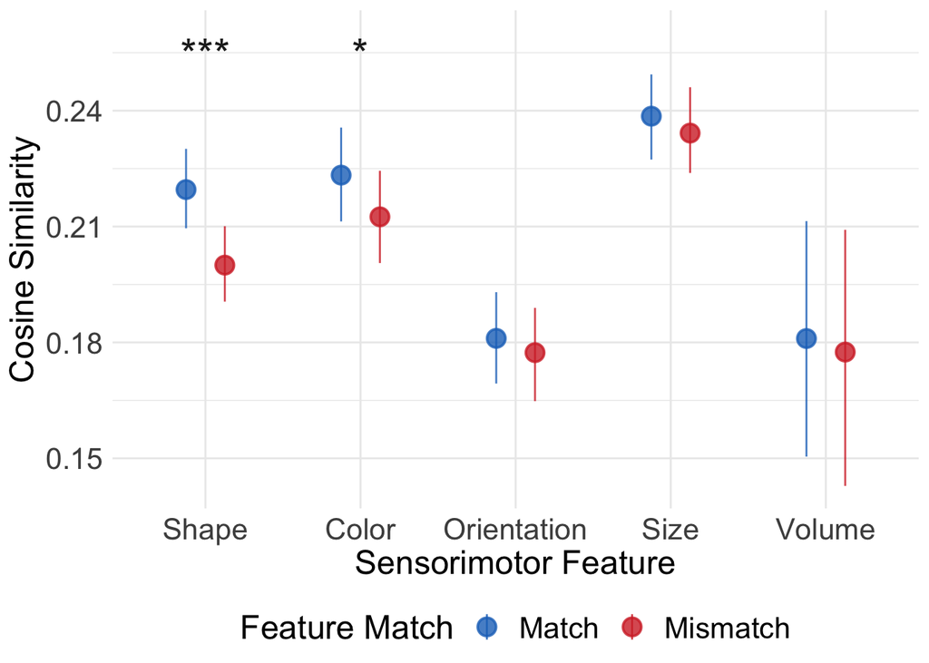

```r
y.signif = range$ymax + 0.01

h1.data %>%
  ggplot(
    aes(x = dataset, y = similarity, color=match)) +
  stat_summary(
    geom="pointrange", fun.data="mean_cl_boot",
    position=position_dodge(width=0.5),
    size=1
  ) +
  theme_minimal() +
  scale_color_manual(
    values = c("match" = colors.match, "mismatch" = colors.mismatch),
    labels=c("Match", "Mismatch")
  ) +
  labs(
    y = "Cosine Similarity",
    x = "Sensorimotor Feature",
    color = "Feature Match"
  ) +
  theme(
    legend.position = "bottom",
    axis.title = element_text(size = 18),  # Increase axis title size
    axis.text = element_text(size = 16),  # Increase axis text size
    axis.text.x = element_text(size = 16),  # Increase axis text size
    legend.text = element_text(size = 16),
    legend.title = element_text(size = 18)
  ) +
  geom_text(data=h1.summary %>%
              mutate(y.signif = y.signif)
            , aes(label = signif_star, y = y.signif), size=8, vjust=1.2, fontface="plain", color="#222222")
```

```r
ggsave("../manuscript/cl/figures/h1.pdf", width = 9, height=5, device="pdf")
```

# 3 H2: Does imagebind text encoder show match/no-match effect for sentence_explicit?

```r
datasets <- c("connell2007", "pecher2006", "muraki2021", "winter2012/e1", "winter2012/e2")
models <- c("ViT-H-14-no-proj")
metric = "cosine"
data_types <- "sentence_explicit"

h2.data <- load_data(models, datasets, metric, data_types)
```

## 3.1 H2A: Aggregate Test

Significant match effect overall.

```r
# Run linear model
h2.agg <- summary(lmer(similarity ~ match + (1 | quadruplet_id) +
                         (1 | dataset), data = h2.data))

summary(h2.agg)
```

```
## Linear mixed model fit by REML. t-tests use Satterthwaite's method [
## lmerModLmerTest]
## Formula: similarity ~ match + (1 | quadruplet_id) + (1 | dataset)
##    Data: h2.data
##
## REML criterion at convergence: -1644.1
##
## Scaled residuals:
##     Min      1Q  Median      3Q     Max
## -3.6208 -0.5188 -0.0119  0.5255  2.9149
##
## Random effects:
##  Groups        Name        Variance Std.Dev.
##  quadruplet_id (Intercept) 0.005715 0.07560
##  dataset       (Intercept) 0.009314 0.09651
##  Residual                  0.001981 0.04451
## Number of obs: 608, groups:  quadruplet_id, 152; dataset, 5
##
## Fixed effects:
##                Estimate Std. Error        df t value Pr(>|t|)
## (Intercept)     0.59011    0.04380   4.00094   13.47 0.000175 ***
## matchmismatch  -0.01018    0.00361 455.00070   -2.82 0.005016 **
## ---
## Signif. codes:  0 '***' 0.001 '**' 0.01 '*' 0.05 '.' 0.1 ' ' 1
##
## Correlation of Fixed Effects:
##             (Intr)
## matchmsmtch -0.041
```

## 3.2 H2B-F: By Feature type

Only shape shows a significant effect.

```r
# Initialize empty data frame to store summarized results
h2.summary <- data.frame()

# Loop through each unique combination of model and dataset
for (dataset_name in unique(h2.data$dataset)) {

  # Subset the data
  subset_data <- h2.data %>%
    filter(dataset == dataset_name)


  # Run linear model
  result <- summary(lmer(similarity ~ match + (1 | quadruplet_id),
                         data = subset_data))

  # Store the summarized t-test result in the data frame
  h2.summary <- rbind(h2.summary, data.frame(
    dataset = dataset_name,
    estimate = result$coefficients[2,1],
    df = result$coefficients[2,3],
    t_value = result$coefficients[2,4],
    p_value = result$coefficients[2,5]
  ))
}

# View the summarized results
h2.summary <- h2.summary %>%
  mutate(
    dataset = factor(dataset, levels=c("Shape", "Color", "Orientation", "Size", "Volume")),
    signif_star = case_when(
      p_value < 0.001 ~ "***",
      p_value < 0.01 ~ "**",
      p_value < 0.05 ~ "*",
      TRUE ~ ""
    )
  )

h2.summary
```

```
##       dataset     estimate        df    t_value    p_value signif_star
## 1       Color -0.013300400  35.00000 -1.4001205 0.17027979
## 2       Shape -0.020420975 179.00000 -3.0509739 0.00262798          **
## 3 Orientation -0.001361195  71.00001 -0.2201214 0.82640831
## 4        Size -0.001190229  95.00000 -0.2783472 0.78135077
## 5      Volume -0.003815655  71.00000 -0.3152541 0.75349348
```

## 3.3 Visualization

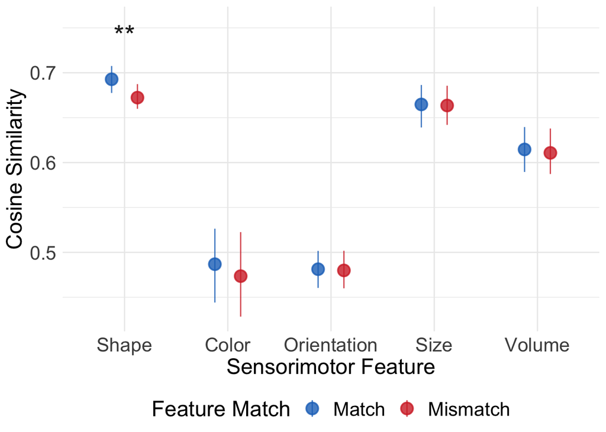

```r
# Get height of bars
range = get_max_min(h2.data)
y.signif = range$ymax + 0.05

h2.data %>%
  ggplot(
    aes(x = dataset, y = similarity, color=match)) +
  stat_summary(
    geom="pointrange", fun.data="mean_cl_boot",
    position=position_dodge(width=0.5),
    size=1
  ) +
  theme_minimal() +
  scale_color_manual(
    values = c("match" = colors.match, "mismatch" = colors.mismatch),
    labels=c("Match", "Mismatch")
  ) +
  labs(
    y = "Cosine Similarity",
    x = "Sensorimotor Feature",
    color = "Feature Match"
  ) +
  theme(
    legend.position = "bottom",
    axis.title = element_text(size = 18),  # Increase axis title size
    axis.text = element_text(size = 16),  # Increase axis text size
    axis.text.x = element_text(size = 16),  # Increase axis text size
    legend.text = element_text(size = 16),
    legend.title = element_text(size = 18)
  ) +
  geom_text(data=h2.summary %>%
              mutate(y.signif = y.signif)
            , aes(label = signif_star, y = y.signif), size=8, vjust=1.2, fontface="plain", color="#222222")
```

```r
ggsave("../manuscript/cl/figures/h2.pdf", width = 9, height=5, device="pdf")
```

# 4 H3: Does imagebind shared space show match/no-match effect for sentence_explicit?

```r
datasets <- c("connell2007", "pecher2006", "muraki2021", "winter2012/e1", "winter2012/e2")
models <- c("ViT-H-14-no-proj", "imagebind")
metric = "cosine"
data_types <- "sentence_explicit"

h3.data <- load_data(models, datasets, metric, data_types) %>%
  mutate(
    model = factor(model, levels=c("imagebind", "ViT-H-14-no-proj"))
  )
```

## 4.1 H3A: Aggregate Test

IB shows mismatch effect overall. Smaller effect than base TE, but difference is n.s.

```r
h3.agg <- summary(lmer(similarity ~ match * model + (1 | quadruplet_id) +
                         (1 | dataset), data = h3.data))

summary(h3.agg)
```

```
## Linear mixed model fit by REML. t-tests use Satterthwaite's method [
## lmerModLmerTest]
## Formula: similarity ~ match * model + (1 | quadruplet_id) + (1 | dataset)
##    Data: h3.data
##
## REML criterion at convergence: -3656.2
##
## Scaled residuals:
##     Min      1Q  Median      3Q     Max
## -4.5341 -0.5684 -0.0291  0.5896  3.6554
##
## Random effects:
##  Groups        Name        Variance Std.Dev.
##  quadruplet_id (Intercept) 0.005311 0.07288
##  dataset       (Intercept) 0.010060 0.10030
##  Residual                  0.001872 0.04327
## Number of obs: 1216, groups:  quadruplet_id, 152; dataset, 5
##
## Fixed effects:
##                                       Estimate Std. Error         df t value
## (Intercept)                          6.598e-01  4.543e-02  4.008e+00  14.524
## matchmismatch                       -9.111e-03  3.510e-03  1.061e+03  -2.596
## modelViT-H-14-no-proj               -6.990e-02  3.510e-03  1.061e+03 -19.916
## matchmismatch:modelViT-H-14-no-proj -1.068e-03  4.964e-03  1.061e+03  -0.215
##                                     Pr(>|t|)
## (Intercept)                         0.000129 ***
## matchmismatch                       0.009569 **
## modelViT-H-14-no-proj                < 2e-16 ***
## matchmismatch:modelViT-H-14-no-proj 0.829615
## ---
## Signif. codes:  0 '***' 0.001 '**' 0.01 '*' 0.05 '.' 0.1 ' ' 1
##
## Correlation of Fixed Effects:
##             (Intr) mtchms mVT-H-
## matchmsmtch -0.039
## mdVT-H-14-- -0.039  0.500
## m:VT-H-14--  0.027 -0.707 -0.707
```

## 4.2 H3B-F: By Feature type

IB shows effect for shape only.

```r
# Initialize empty data frame to store summarized results
h3.ib.summary <- data.frame()
h3.model.summary <- data.frame()

# Loop through each unique combination of model and dataset
for (dataset_name in unique(h3.data$dataset)) {

  # Subset the data
  subset_data <- h3.data %>%
    filter(dataset == dataset_name)


  # Run linear model
  result <- summary(lmer(similarity ~ match * model + (1 | quadruplet_id),
                         data = subset_data))

  # Store the summarized t-test result in the data frame
  h3.ib.summary <- rbind(h3.ib.summary, data.frame(
    dataset = dataset_name,
    estimate = result$coefficients[2,1],
    df = result$coefficients[2,3],
    t_value = result$coefficients[2,4],
    p_value = result$coefficients[2,5]
  ))

  h3.model.summary <- rbind(h3.model.summary, data.frame(
    dataset = dataset_name,
    estimate = result$coefficients[4,1],
    df = result$coefficients[4,3],
    t_value = result$coefficients[4,4],
    p_value = result$coefficients[4,5]
  ))
}

# View the summarized results
h3.ib.summary <- h3.ib.summary %>%
  mutate(
    dataset = factor(dataset, levels=c("Shape", "Color", "Orientation", "Size", "Volume")),
    signif_star = case_when(
      p_value < 0.001 ~ "***",
      p_value < 0.01 ~ "**",
      p_value < 0.05 ~ "*",
      TRUE ~ ""
    )
  )

h3.ib.summary
```

```
##       dataset      estimate       df     t_value    p_value signif_star
## 1       Color -0.0132238917  81.0000 -1.36201452 0.17696916
## 2       Shape -0.0178667458 417.0000 -2.98857531 0.00296854          **
## 3 Orientation -0.0005992612 164.9994 -0.09367739 0.92547908
## 4        Size -0.0012141189 221.0000 -0.26890718 0.78825198
## 5      Volume -0.0042030170 165.0000 -0.32876745 0.74274837
```

IB !> TE for any of the features.

```r
# View the summarized results
h3.model.summary <- h3.model.summary %>%
  mutate(
    dataset = factor(dataset, levels=c("Shape", "Color", "Orientation", "Size", "Volume")),
    signif_star = case_when(
      p_value < 0.001 ~ "***",
      p_value < 0.01 ~ "**",
      p_value < 0.05 ~ "*",
      TRUE ~ ""
    )
  )

h3.model.summary
```

```
##       dataset      estimate       df      t_value   p_value signif_star
## 1       Color -7.650865e-05  81.0000 -0.005572088 0.9955678
## 2       Shape -2.554229e-03 417.0000 -0.302108930 0.7627196
## 3 Orientation -7.619339e-04 164.9994 -0.084221098 0.9329827
## 4        Size  2.389020e-05 221.0000  0.003741501 0.9970181
## 5      Volume  3.873615e-04 165.0000  0.021425410 0.9829322
```

## 4.3 Visualization

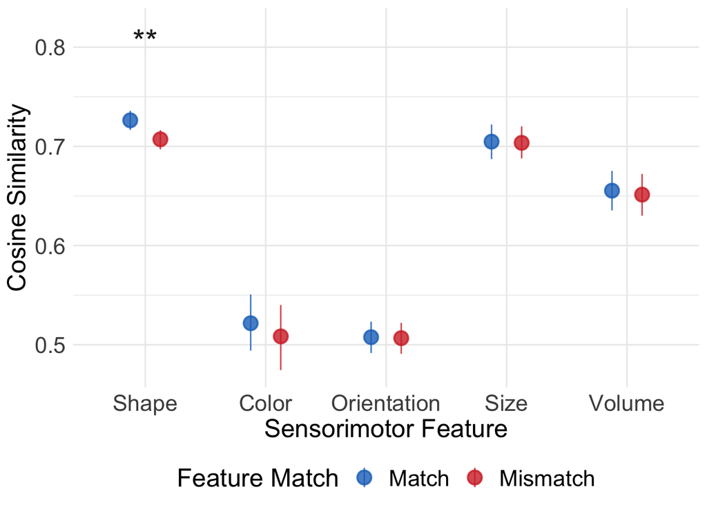

```r
# Get height of bars
range = get_max_min(h3.data)
y.signif = range$ymax + 0.05

h3.data %>%
  ggplot(
    aes(x = dataset, y = similarity, color=match)) +
  stat_summary(
    geom="pointrange", fun.data="mean_cl_boot",
    position=position_dodge(width=0.5),
    size=1
  ) +
  theme_minimal() +
  scale_color_manual(
    values = c("match" = colors.match, "mismatch" = colors.mismatch),
    labels=c("Match", "Mismatch")
  ) +
  labs(
    y = "Cosine Similarity",
    x = "Sensorimotor Feature",
    color = "Feature Match"
  ) +
  theme(
    legend.position = "bottom",
    axis.title = element_text(size = 18),  # Increase axis title size
    axis.text = element_text(size = 16),  # Increase axis text size
    axis.text.x = element_text(size = 16),  # Increase axis text size
    legend.text = element_text(size = 16),
    legend.title = element_text(size = 18)
  ) +
  geom_text(data=h3.ib.summary %>%
              mutate(y.signif = y.signif)
            , aes(label = signif_star, y = y.signif), size=8, vjust=1.2, fontface="plain", color="#222222")
```

```r
ggsave("../manuscript/cl/figures/h3.pdf", width = 9, height=5, device="pdf")
```

# 5 H4: Does imagebind show match/no-match effect for media_explicit?

```r
datasets <- c("connell2007", "pecher2006", "muraki2021", "winter2012/e1", "winter2012/e2")
models <- c("imagebind")
metric = "cosine"
data_types <- "explicit_media"

h4.data <- load_data(models, datasets, metric, data_types)
```

## 5.1 H4A: Aggregate Test

Significant match effect overall.

```r
h4.agg <- summary(lmer(similarity ~ match + (1 | quadruplet_id) +
                         (1 | dataset), data = h4.data))

summary(h4.agg)
```

```
## Linear mixed model fit by REML. t-tests use Satterthwaite's method [
## lmerModLmerTest]
## Formula: similarity ~ match + (1 | quadruplet_id) + (1 | dataset)
##    Data: h4.data
##
## REML criterion at convergence: -1956.7
##
## Scaled residuals:
##      Min       1Q   Median       3Q      Max
## -2.76524 -0.51234  0.01894  0.53278  3.07492
##
## Random effects:
##  Groups        Name        Variance Std.Dev.
##  quadruplet_id (Intercept) 0.002308 0.04804
##  dataset       (Intercept) 0.001742 0.04174
##  Residual                  0.001333 0.03650
## Number of obs: 608, groups:  quadruplet_id, 152; dataset, 5
##
## Fixed effects:
##                 Estimate Std. Error         df t value Pr(>|t|)
## (Intercept)     0.253390   0.019312   4.014161  13.121 0.000191 ***
## matchmismatch  -0.018977   0.002961 455.000061  -6.409 3.66e-10 ***
## ---
## Signif. codes:  0 '***' 0.001 '**' 0.01 '*' 0.05 '.' 0.1 ' ' 1
##
## Correlation of Fixed Effects:
##             (Intr)
## matchmsmtch -0.077
```

## 5.2 H4B-F: By Feature type

Explicit match effect for color, shape, & orientation. Not volume or size.

```r
# Initialize empty data frame to store summarized results
h4.summary <- data.frame()

# Loop through each unique combination of model and dataset
for (dataset_name in unique(h4.data$dataset)) {

  # Subset the data
  subset_data <- h4.data %>%
    filter(dataset == dataset_name)


  # Run linear model
  result <- summary(lmer(similarity ~ match + (1 | quadruplet_id),
                         data = subset_data))

  # Store the summarized t-test result in the data frame
  h4.summary <- rbind(h4.summary, data.frame(
    dataset = dataset_name,
    estimate = result$coefficients[2,1],
    df = result$coefficients[2,3],
    t_value = result$coefficients[2,4],
    p_value = result$coefficients[2,5]
  ))
}

# View the summarized results
h4.summary <- h4.summary %>%
  mutate(
    dataset = factor(dataset, levels=c("Shape", "Color", "Orientation", "Size", "Volume")),
    signif_star = case_when(
      p_value < 0.001 ~ "***",
      p_value < 0.01 ~ "**",
      p_value < 0.05 ~ "*",
      TRUE ~ ""
    )
  )

h4.summary
```

```
##       dataset     estimate        df    t_value      p_value signif_star
## 1       Color -0.054629286  35.00000 -8.7981226 2.162509e-10         ***
## 2       Shape -0.026781395 179.00000 -5.1121564 8.131064e-07         ***
## 3 Orientation -0.020483573  71.00000 -5.9249961 1.022383e-07         ***
## 4        Size -0.002694642  95.00001 -0.6821070 4.968310e-01
## 5      Volume -0.001842954  71.00000 -0.1731506 8.630257e-01
```

## 5.3 Visualization

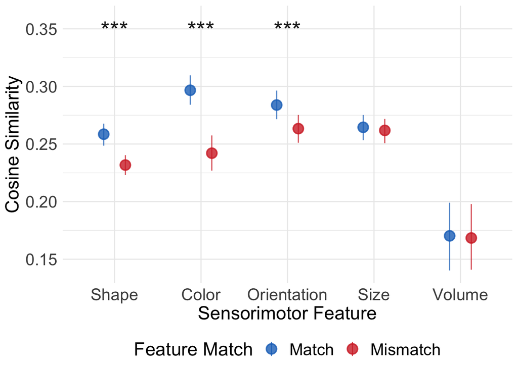

```r
# Get height of bars
range = get_max_min(h4.data)
y.signif = range$ymax + 0.05

h4.data %>%
  ggplot(
    aes(x = dataset, y = similarity, color=match)) +
  stat_summary(
    geom="pointrange", fun.data="mean_cl_boot",
    position=position_dodge(width=0.5),
    size=1
  ) +
  theme_minimal() +
  scale_color_manual(
    values = c("match" = colors.match, "mismatch" = colors.mismatch),
    labels=c("Match", "Mismatch")
  ) +
  labs(
    y = "Cosine Similarity",
    x = "Sensorimotor Feature",
    color = "Feature Match"
  ) +
  theme(
    legend.position = "bottom",
    axis.title = element_text(size = 18),  # Increase axis title size
    axis.text = element_text(size = 16),  # Increase axis text size
    axis.text.x = element_text(size = 16),  # Increase axis text size
    legend.text = element_text(size = 16),
    legend.title = element_text(size = 18)
  ) +
  geom_text(data=h4.summary %>%
              mutate(y.signif = y.signif)
            , aes(label = signif_star, y = y.signif), size=8, vjust=1.2, fontface="plain", color="#222222")
```

```r
ggsave("../manuscript/cl/figures/h4.pdf", width = 9, height=5, device="pdf")
```

## 5.4 Combined H2-4 Visualization

### 5.4.1 Match vs no-match

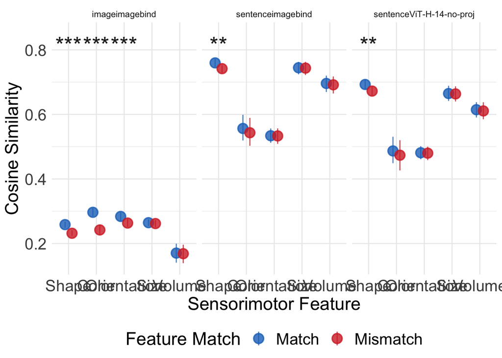

```r
h234.data <- rbind(h3.data %>% mutate(modality="sentence"),
                   h4.data %>% mutate(modality="image")) %>%
  mutate(
    hypothesis = paste0(modality, model)
  )

h234.summary <- rbind(
  h2.summary %>% mutate(modality="sentence", model="ViT-H-14-no-proj"),
  h3.ib.summary %>% mutate(modality="sentence",
                         model = "imagebind"),
  h4.summary %>% mutate(modality="image", model="imagebind")
  ) %>%
  mutate(
    hypothesis = paste0(modality, model)
  )

# Get height of bars
y.signif = 0.85

h234.data %>%
  ggplot(
    aes(x = dataset, y = similarity, color=match)) +
  stat_summary(
    geom="pointrange", fun.data="mean_cl_boot",
    position=position_dodge(width=0.5),
    size=1
  ) +
  theme_minimal() +
  scale_color_manual(
    values = c("match" = colors.match, "mismatch" = colors.mismatch),
    labels=c("Match", "Mismatch")
  ) +
  labs(
    y = "Cosine Similarity",
    x = "Sensorimotor Feature",
    color = "Feature Match"
  ) +
  theme(
    legend.position = "bottom",
    axis.title = element_text(size = 18),  # Increase axis title size
    axis.text = element_text(size = 16),  # Increase axis text size
    axis.text.x = element_text(size = 16),  # Increase axis text size
    legend.text = element_text(size = 16),
    legend.title = element_text(size = 18)
  ) +
  geom_text(data=h234.summary %>%
              mutate(y.signif = y.signif)
            , aes(label = signif_star, y = y.signif), size=8, vjust=1.2, fontface="plain", color="#222222") +
  facet_grid(
    . ~ hypothesis
  )
```

```r
ggsave("../manuscript/cl/figures/h234.pdf", width = 9, height=5, device="pdf")
```

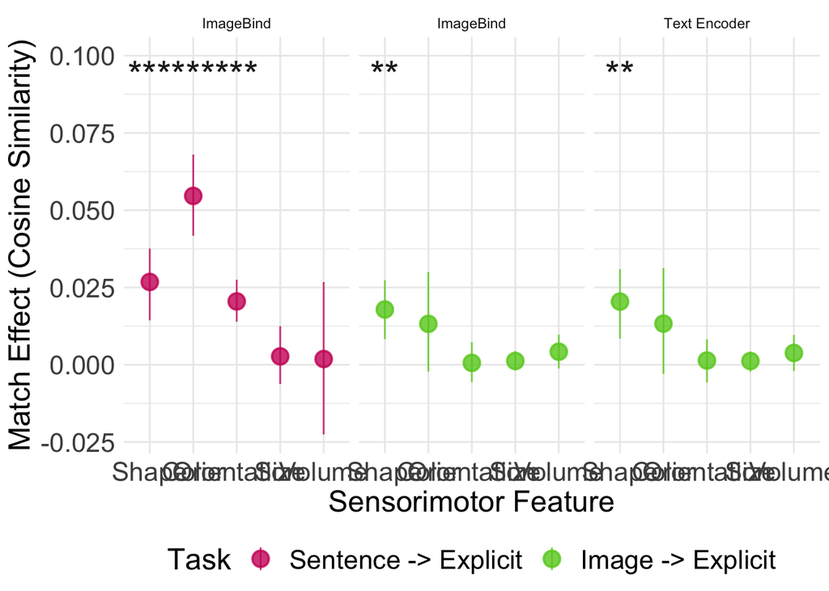

```r
h234.data.diff <- h234.data %>%
  group_by(
    dataset, item, item_type, sent_condition, model, modality, hypothesis
  ) %>%
  arrange(match) %>%
  summarize(
    s_diff = first(similarity) - last(similarity),
    .groups="drop"
  )

h234.summary <- rbind(
  h2.summary %>% mutate(modality="sentence", model="ViT-H-14-no-proj"),
  h3.ib.summary %>% mutate(modality="sentence",
                         model = "imagebind"),
  h4.summary %>% mutate(modality="image", model="imagebind")
  ) %>%
  mutate(
    hypothesis = paste0(modality, model)
  )

# Get height of bars
y.signif = 0.1

h234.data.diff %>%
  ggplot(
    aes(x = dataset, y = s_diff, color=modality)) +
  stat_summary(
    geom="pointrange", fun.data="mean_cl_boot",
    position=position_dodge(width=0.5),
    size=1
  ) +
  theme_minimal() +
  scale_color_manual(
    values = c("sentence" = colors.llm, "image" = colors.ib),
    labels=c("Sentence -> Explicit", "Image -> Explicit")
  ) +
  labs(
    y = "Match Effect (Cosine Similarity)",
    x = "Sensorimotor Feature",
    color = "Task"
  ) +
  theme(
    legend.position = "bottom",
    axis.title = element_text(size = 18),  # Increase axis title size
    axis.text = element_text(size = 16),  # Increase axis text size
    axis.text.x = element_text(size = 16),  # Increase axis text size
    legend.text = element_text(size = 16),
    legend.title = element_text(size = 18)
  ) +
  geom_text(data=h234.summary %>%
              mutate(y.signif = y.signif)
            , aes(label = signif_star, y = y.signif), size=8, vjust=1.2, fontface="plain", color="#222222") +
  facet_grid(
    . ~ hypothesis
    ,
    labeller = function(variable, value) {
      return(c(
        "imageimagebind" = "ImageBind",
        "sentenceimagebind" = "ImageBind",
          "sentenceViT-H-no-proj" = "Text Encoder"

      ))
    }
  )
```

```r
ggsave("../manuscript/cl/figures/h234.pdf", width = 9, height=5, device="pdf")
```

# 6 H5: Does imagebind text encoder explain human effects?

```r
datasets <- c("muraki2021", "pecher2006", "winter2012/e1", "winter2012/e2")
models <- c("ViT-H-14-no-proj")
metric = "cosine"
data_types <- "sentence_explicit"

h5.data <- load_data(models, datasets, metric, data_types)

h5.human_data <- human_data %>%
  merge(
    h5.data %>% select(item_id, similarity, model), by="item_id"
  )
```

## 6.1 H5A: Aggregate

### 6.1.1 Reproduction of original result

original match effect is significant.

```r
m5.a.base <- lmer(rt ~ 1 + (1  | ppt_id) +
                    (1 | quadruplet_id),
                  data=h5.human_data, REML=FALSE)

m5.a <- lmer(rt ~ match + (1  | ppt_id) +
               (1 | quadruplet_id),
                  data=h5.human_data, REML=FALSE)

anova(m5.a, m5.a.base)
```

```
## Data: h5.human_data
## Models:
## m5.a.base: rt ~ 1 + (1 | ppt_id) + (1 | quadruplet_id)
## m5.a: rt ~ match + (1 | ppt_id) + (1 | quadruplet_id)
##           npar    AIC    BIC  logLik deviance  Chisq Df Pr(>Chisq)
## m5.a.base    4 252397 252428 -126194   252389
## m5.a         5 252335 252373 -126162   252325 63.926  1  1.292e-15 ***
## ---
## Signif. codes:  0 '***' 0.001 '**' 0.01 '*' 0.05 '.' 0.1 ' ' 1
```

```r
summary(m5.a)
```

```
## Linear mixed model fit by maximum likelihood . t-tests use Satterthwaite's
##   method [lmerModLmerTest]
## Formula: rt ~ match + (1 | ppt_id) + (1 | quadruplet_id)
##    Data: h5.human_data
##
##       AIC       BIC    logLik  deviance  df.resid
##  252334.7  252373.4 -126162.3  252324.7     16983
##
## Scaled residuals:
##     Min      1Q  Median      3Q     Max
## -3.1388 -0.6056 -0.1683  0.3736  5.5502
##
## Random effects:
##  Groups        Name        Variance Std.Dev.
##  ppt_id        (Intercept)  81999   286.4
##  quadruplet_id (Intercept)  18859   137.3
##  Residual                  145359   381.3
## Number of obs: 16988, groups:  ppt_id, 738; quadruplet_id, 89
##
## Fixed effects:
##               Estimate Std. Error       df t value Pr(>|t|)
## (Intercept)    1001.58      20.56   130.23  48.714  < 2e-16 ***
## matchmismatch    47.06       5.88 16175.21   8.004 1.29e-15 ***
## ---
## Signif. codes:  0 '***' 0.001 '**' 0.01 '*' 0.05 '.' 0.1 ' ' 1
##
## Correlation of Fixed Effects:
##             (Intr)
## matchmsmtch -0.143
```

### 6.1.2 Text-encoder baseline

Match effect is significant when controlling for similarity.

Similarity is also significant.

```r
m5.a.sim.base <- lmer(rt ~ 1 + similarity + (1  | ppt_id) +
                    (1 | quadruplet_id),
                  data=h5.human_data, REML=FALSE)

m5.a.sim <- lmer(rt ~ match + similarity + (1  | ppt_id) +
               (1 | quadruplet_id),
                  data=h5.human_data, REML=FALSE)

anova(m5.a.sim, m5.a.sim.base)
```

```
## Data: h5.human_data
## Models:
## m5.a.sim.base: rt ~ 1 + similarity + (1 | ppt_id) + (1 | quadruplet_id)
## m5.a.sim: rt ~ match + similarity + (1 | ppt_id) + (1 | quadruplet_id)
##               npar    AIC    BIC  logLik deviance Chisq Df Pr(>Chisq)
## m5.a.sim.base    5 252357 252395 -126173   252347
## m5.a.sim         6 252307 252353 -126147   252295 52.15  1  5.141e-13 ***
## ---
## Signif. codes:  0 '***' 0.001 '**' 0.01 '*' 0.05 '.' 0.1 ' ' 1
```

```r
summary(m5.a.sim)
```

```
## Linear mixed model fit by maximum likelihood . t-tests use Satterthwaite's
##   method [lmerModLmerTest]
## Formula: rt ~ match + similarity + (1 | ppt_id) + (1 | quadruplet_id)
##    Data: h5.human_data
##
##       AIC       BIC    logLik  deviance  df.resid
##  252306.6  252353.0 -126147.3  252294.6     16982
##
## Scaled residuals:
##     Min      1Q  Median      3Q     Max
## -3.1521 -0.6031 -0.1684  0.3706  5.5547
##
## Random effects:
##  Groups        Name        Variance Std.Dev.
##  ppt_id        (Intercept)  82071   286.5
##  quadruplet_id (Intercept)  20699   143.9
##  Residual                  145019   380.8
## Number of obs: 16988, groups:  ppt_id, 738; quadruplet_id, 89
##
## Fixed effects:
##                Estimate Std. Error        df t value Pr(>|t|)
## (Intercept)    1224.769     45.960   829.599  26.648  < 2e-16 ***
## matchmismatch    42.822      5.923 16242.195   7.229 5.08e-13 ***
## similarity     -378.888     68.773  2658.285  -5.509 3.95e-08 ***
## ---
## Signif. codes:  0 '***' 0.001 '**' 0.01 '*' 0.05 '.' 0.1 ' ' 1
##
## Correlation of Fixed Effects:
##             (Intr) mtchms
## matchmsmtch -0.178
## similarity  -0.887  0.130
```

R^2 for both is tiny.

```r
r.squaredGLMM(m5.a.sim.base, m5.a.base)
```

```
##            R2m       R2c
## [1,] 0.0108846 0.4216487
```

```r
r.squaredGLMM(m5.a.sim, m5.a.base)
```

```
##             R2m       R2c
## [1,] 0.01004957 0.4206282
```

## 6.2 H5B-F: By dataset

Signif match effects everywhere. Signif similarity effects just for shape.

```r
# Initialize empty data frame to store summarized results
h5.summary <- data.frame()

# Loop through each unique combination of model and dataset
for (dataset_name in unique(h5.human_data$dataset)) {

  # Subset the data
  subset_data <- h5.human_data %>%
    filter(dataset == dataset_name)


  m5.b.sim.base <- lmer(rt ~ 1 + similarity + (1  | ppt_id) +
                    (1 | quadruplet_id),
                  data=subset_data, REML=FALSE)

  m5.b.sim <- lmer(rt ~ match + similarity + (1  | ppt_id) +
               (1 | quadruplet_id),
                  data=subset_data, REML=FALSE)

  result = summary(m5.b.sim)
  a5b <- anova(m5.b.sim, m5.b.sim.base)

  # Store the summarized t-test result in the data frame
  h5.summary <- rbind(h5.summary, data.frame(
    dataset = dataset_name,
    effect = "matchmismatch",
    estimate = result$coefficients[2,1],
    df = a5b$Df[2],
    chisq = a5b$Chisq[2],
    p_value = a5b$`Pr(>Chisq)`[2]
  ))

  # Effects of similarity
  h5.summary <- rbind(h5.summary, data.frame(
    dataset = dataset_name,
    effect = "similarity",
    estimate = result$coefficients[3,1],
    df = result$coefficients[3,3],
    chisq = "-",
    p_value = result$coefficients[3,5]
  ))
}

# View the summarized results
h5.summary <- h5.summary %>%
  mutate(
    dataset = factor(dataset, levels=c("Shape", "Color", "Orientation", "Size", "Volume"))
  ) %>%
  arrange(effect)

h5.summary
```

```
##       dataset        effect   estimate         df            chisq      p_value
## 1 Orientation matchmismatch   27.95451    1.00000 11.1971070962318 8.192495e-04
## 2       Shape matchmismatch   50.06683    1.00000 30.0613169206918 4.185985e-08
## 3        Size matchmismatch   64.27923    1.00000 5.25452663032047 2.188975e-02
## 4      Volume matchmismatch   68.25655    1.00000 7.66171649921853 5.640482e-03
## 5 Orientation    similarity  -56.92044  227.82637                - 6.798757e-01
## 6       Shape    similarity -513.15087 4500.39391                - 2.316760e-08
## 7        Size    similarity -468.82365   48.42314                - 2.538613e-01
## 8      Volume    similarity -399.93595  449.39554                - 7.015087e-02
```

## 6.3 Visualization

[Note: does the way I’ve residualized make sense here? If I use the lmer the REs suck up all the variance.]

[CIs are artificially large due to item-wise averaging]

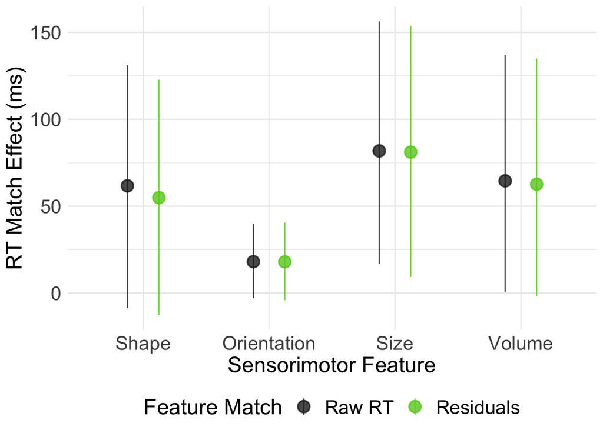

```r
h5.human_data$rt_resid <- summary(lm(rt ~ similarity*dataset, data=h5.human_data))$resid

h5.human_data %>%
  mutate(
    item_no_match = str_extract(item_id, "[A-z]+_[0-9]+_[ab]")
  ) %>%
  group_by(item_no_match, dataset, match) %>%
  summarize(
    rt = mean(rt),
    rt_resid = mean(rt_resid)
  ) %>%
  pivot_wider(names_from="match", values_from=c("rt", "rt_resid")) %>%
  mutate(
    rt_diff = rt_mismatch - rt_match,
    rt_resid_diff = rt_resid_mismatch - rt_resid_match
  ) %>%
  pivot_longer(
    cols = c(rt_diff, rt_resid_diff)
  ) %>%
  ggplot(aes(x = dataset, y = value, color = name)) +
  stat_summary(geom="pointrange", fun.data="mean_cl_boot",
               position = position_dodge(width=0.5), size=1) +
  theme_minimal() +
  scale_color_manual(
    values = c("rt_diff" = colors.human, "rt_resid_diff" = colors.llm),
    labels=c("Raw RT", "Residuals")
  ) +
  labs(
    y = "RT Match Effect (ms)",
    x = "Sensorimotor Feature",
    color = "Feature Match"
  ) +
  theme(
    legend.position = "bottom",
    axis.title = element_text(size = 18),  # Increase axis title size
    axis.text = element_text(size = 16),  # Increase axis text size
    axis.text.x = element_text(size = 16),  # Increase axis text size
    legend.text = element_text(size = 16),
    legend.title = element_text(size = 18)
  )
```

# 7 H6: Does imagebind full model explain human effects?

```r
datasets <- c("muraki2021", "pecher2006", "winter2012/e1", "winter2012/e2")
models <- c("imagebind")
metric = "cosine"
data_types <- "sentence_media"

h6.data <- load_data(models, datasets, metric, data_types)

h6.human_data <- human_data %>%
  merge(
    h6.data %>% select(item_id, similarity, model), by="item_id"
  )
```

## 7.1 H6A: Aggregate

Signif effect of match over IB similarity.

```r
m6.a.sim.base <- lmer(rt ~ 1 + similarity + (1  | ppt_id) +
                    (1 | quadruplet_id),
                  data=h6.human_data, REML=FALSE)

m6.a.sim <- lmer(rt ~ match + similarity + (1  | ppt_id) +
               (1 | quadruplet_id),
                  data=h6.human_data, REML=FALSE)

anova(m6.a.sim, m6.a.sim.base)
```

```
## Data: h6.human_data
## Models:
## m6.a.sim.base: rt ~ 1 + similarity + (1 | ppt_id) + (1 | quadruplet_id)
## m6.a.sim: rt ~ match + similarity + (1 | ppt_id) + (1 | quadruplet_id)
##               npar    AIC    BIC  logLik deviance  Chisq Df Pr(>Chisq)
## m6.a.sim.base    5 252294 252332 -126142   252284
## m6.a.sim         6 252257 252304 -126123   252245 38.405  1  5.749e-10 ***
## ---
## Signif. codes:  0 '***' 0.001 '**' 0.01 '*' 0.05 '.' 0.1 ' ' 1
```

```r
summary(m6.a.sim)
```

```
## Linear mixed model fit by maximum likelihood . t-tests use Satterthwaite's
##   method [lmerModLmerTest]
## Formula: rt ~ match + similarity + (1 | ppt_id) + (1 | quadruplet_id)
##    Data: h6.human_data
##
##       AIC       BIC    logLik  deviance  df.resid
##  252257.1  252303.6 -126122.6  252245.1     16982
##
## Scaled residuals:
##     Min      1Q  Median      3Q     Max
## -3.2847 -0.6040 -0.1679  0.3764  5.6265
##
## Random effects:
##  Groups        Name        Variance Std.Dev.
##  ppt_id        (Intercept)  81943   286.3
##  quadruplet_id (Intercept)  19276   138.8
##  Residual                  144637   380.3
## Number of obs: 16988, groups:  ppt_id, 738; quadruplet_id, 89
##
## Fixed effects:
##                Estimate Std. Error        df t value Pr(>|t|)
## (Intercept)    1166.567     27.771   333.110  42.007  < 2e-16 ***
## matchmismatch    37.038      5.972 16249.578   6.202  5.7e-10 ***
## similarity     -823.517     92.207  4285.207  -8.931  < 2e-16 ***
## ---
## Signif. codes:  0 '***' 0.001 '**' 0.01 '*' 0.05 '.' 0.1 ' ' 1
##
## Correlation of Fixed Effects:
##             (Intr) mtchms
## matchmsmtch -0.229
## similarity  -0.667  0.188
```

## 7.2 H6B-D: By dataset

Match effect survives in each case.

```r
# Initialize empty data frame to store summarized results
h6.summary <- data.frame()

# Loop through each unique combination of model and dataset
for (dataset_name in unique(h6.human_data$dataset)) {

  # Subset the data
  subset_data <- h6.human_data %>%
    filter(dataset == dataset_name)


  m6.b.sim.base <- lmer(rt ~ 1 + similarity + (1  | ppt_id) +
                    (1 | quadruplet_id),
                  data=subset_data, REML=FALSE)

  m6.b.sim <- lmer(rt ~ match + similarity + (1  | ppt_id) +
               (1 | quadruplet_id),
                  data=subset_data, REML=FALSE)

  result = summary(m6.b.sim)
  a6b <- anova(m6.b.sim, m6.b.sim.base)

  # Store the summarized t-test result in the data frame
  h6.summary <- rbind(h6.summary, data.frame(
    dataset = dataset_name,
    estimate = result$coefficients[2,1],
    df = a6b$Df[2],
    chisq = a6b$Chisq[2],
    p_value = a6b$`Pr(>Chisq)`[2]
  ))
}

# View the summarized results
h6.summary <- h6.summary %>%
  mutate(
    dataset = factor(dataset, levels=c("Shape", "Color", "Orientation", "Size", "Volume"))
  )

h6.summary
```

```
##       dataset estimate df     chisq      p_value
## 1 Orientation 27.13244  1 10.482266 0.0012052581
## 2       Shape 36.89060  1 15.878448 0.0000675435
## 3        Size 64.03573  1  5.202780 0.0225507911
## 4      Volume 68.87889  1  7.757867 0.0053479082
```

## 7.3 Visualization

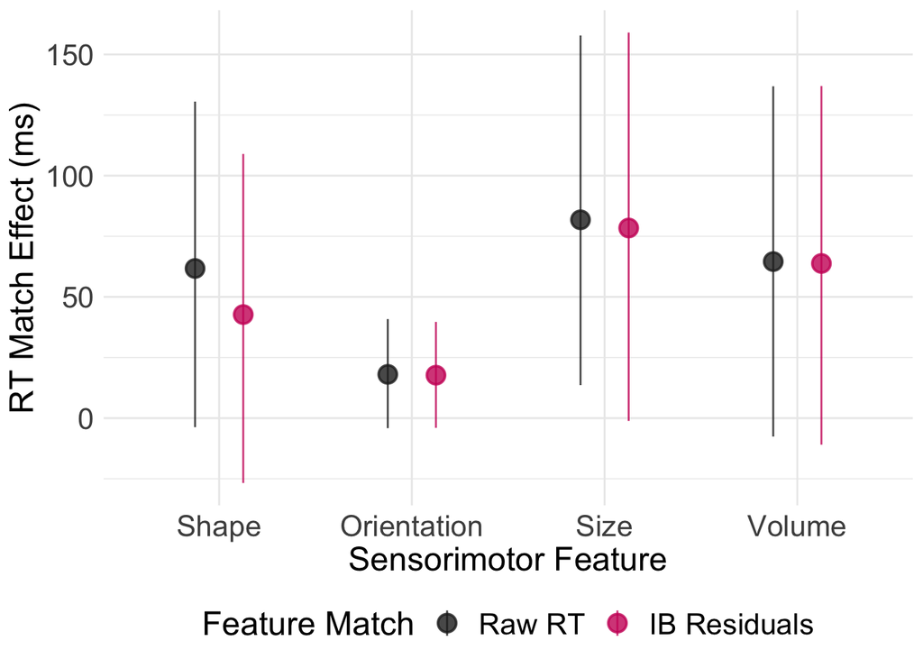

```r
h6.human_data$rt_resid <- summary(lm(rt ~ similarity*dataset, data=h6.human_data))$resid

h6.human_data %>%
  mutate(
    item_no_match = str_extract(item_id, "[A-z]+_[0-9]+_[ab]")
  ) %>%
  group_by(item_no_match, dataset, match) %>%
  summarize(
    rt = mean(rt),
    rt_resid = mean(rt_resid)
  ) %>%
  pivot_wider(names_from="match", values_from=c("rt", "rt_resid")) %>%
  mutate(
    rt_diff = rt_mismatch - rt_match,
    rt_resid_diff = rt_resid_mismatch - rt_resid_match
  ) %>%
  pivot_longer(
    cols = c(rt_diff, rt_resid_diff)
  ) %>%
  ggplot(aes(x = dataset, y = value, color = name)) +
  stat_summary(geom="pointrange", fun.data="mean_cl_boot",
               position = position_dodge(width=0.5), size=1) +
  theme_minimal() +
  scale_color_manual(
    values = c("rt_diff" = colors.human, "rt_resid_diff" = colors.ib),
    labels=c("Raw RT", "IB Residuals")
  ) +
  labs(
    y = "RT Match Effect (ms)",
    x = "Sensorimotor Feature",
    color = "Feature Match"
  ) +
  theme(
    legend.position = "bottom",
    axis.title = element_text(size = 18),  # Increase axis title size
    axis.text = element_text(size = 16),  # Increase axis text size
    axis.text.x = element_text(size = 16),  # Increase axis text size
    legend.text = element_text(size = 16),
    legend.title = element_text(size = 18)
  )
```

## 7.4 H5-6 Combined Visualization

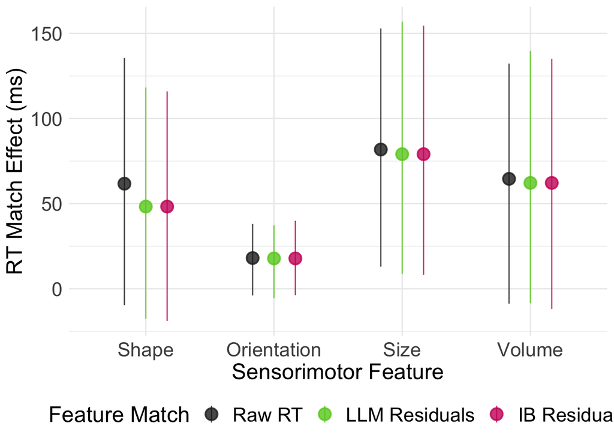

```r
h6.human_data$rt_resid_ib <- summary(lm(rt ~ similarity*dataset, data=h6.human_data))$resid

h6.human_data$rt_resid_te <- summary(lm(rt ~ similarity*dataset, data=h5.human_data))$resid

h6.human_data %>%
  mutate(
    item_no_match = str_extract(item_id, "[A-z]+_[0-9]+_[ab]")
  ) %>%
  group_by(item_no_match, dataset, match) %>%
  summarize(
    rt = mean(rt),
    rt_resid_ib = mean(rt_resid_ib),
    rt_resid_te = mean(rt_resid_te)
  ) %>%
  pivot_wider(
    names_from="match",
    values_from=c("rt", "rt_resid_ib", "rt_resid_te")
  ) %>%
  mutate(
    rt_diff = rt_mismatch - rt_match,
    rt_resid_ib_diff = rt_resid_ib_mismatch - rt_resid_te_match,
    rt_resid_te_diff = rt_resid_ib_mismatch - rt_resid_te_match
  ) %>%
  pivot_longer(
    cols = c(rt_diff, rt_resid_te_diff, rt_resid_ib_diff)
  ) %>%
  mutate(
    name = factor(name, levels=c("rt_diff", "rt_resid_te_diff", "rt_resid_ib_diff"))
  ) %>%
  ggplot(aes(x = dataset, y = value, color = name)) +
  stat_summary(geom="pointrange", fun.data="mean_cl_boot",
               position = position_dodge(width=0.5), size=1) +
  theme_minimal() +
  scale_color_manual(
    values = c(
      "rt_diff" = colors.human,
      "rt_resid_te_diff" = colors.llm,
      "rt_resid_ib_diff" = colors.ib
      ),
    labels=c("Raw RT", "LLM Residuals", "IB Residuals")
  ) +
  labs(
    y = "RT Match Effect (ms)",
    x = "Sensorimotor Feature",
    color = "Feature Match"
  ) +
  theme(
    legend.position = "bottom",
    axis.title = element_text(size = 18),  # Increase axis title size
    axis.text = element_text(size = 16),  # Increase axis text size
    axis.text.x = element_text(size = 16),  # Increase axis text size
    legend.text = element_text(size = 16),
    legend.title = element_text(size = 18)
  )
```

# 8 H7: Do models with closer modality integration perform better?

Import data

```r
datasets <- c("connell2007", "pecher2006", "muraki2021", "winter2012/e1")
models <- c("ViT-B-32", "vilt", "bridgetower")
metric = "softmax"
data_types <- "sentence_media"

h7.data <- load_data(models, datasets, metric, data_types)
```

## 8.1 H7A: Match sensitivity

### 8.1.1 Aggregate

No overall pairwise interaction effects of any model:match.

#### 8.1.1.1 CLIP vs BT

```r
summary(lm(similarity ~ match * model,
             data = h7.data %>%
               filter(model %in% c("ViT-B-32", "bridgetower"))
        ))
```

```
##
## Call:
## lm(formula = similarity ~ match * model, data = h7.data %>% filter(model %in%
##     c("ViT-B-32", "bridgetower")))
##
## Residuals:
##     Min      1Q  Median      3Q     Max
## -0.5459 -0.2601  0.0000  0.2601  0.5459
##
## Coefficients:
##                                Estimate Std. Error t value Pr(>|t|)
## (Intercept)                     0.53552    0.01974  27.123   <2e-16 ***
## matchmismatch                  -0.07104    0.02792  -2.544   0.0111 *
## modelbridgetower                0.01181    0.02792   0.423   0.6725
## matchmismatch:modelbridgetower -0.02361    0.03949  -0.598   0.5500
## ---
## Signif. codes:  0 '***' 0.001 '**' 0.01 '*' 0.05 '.' 0.1 ' ' 1
##
## Residual standard error: 0.3159 on 1020 degrees of freedom
## Multiple R-squared:  0.01731,    Adjusted R-squared:  0.01442
## F-statistic: 5.989 on 3 and 1020 DF,  p-value: 0.0004795
```

#### 8.1.1.2 BT vs ViLT

```r
summary(lm(similarity ~ match * model,
             data = h7.data %>%
               filter(model %in% c("bridgetower", "vilt"))
        ))
```

```
##
## Call:
## lm(formula = similarity ~ match * model, data = h7.data %>% filter(model %in%
##     c("bridgetower", "vilt")))
##
## Residuals:
##     Min      1Q  Median      3Q     Max
## -0.5561 -0.3051  0.0000  0.3051  0.5561
##
## Coefficients:
##                                 Estimate Std. Error t value Pr(>|t|)
## (Intercept)                     0.556119   0.021252  26.168  < 2e-16 ***
## matchmismatch                  -0.112239   0.030054  -3.735 0.000198 ***
## modelbridgetower               -0.008791   0.030054  -0.293 0.769952
## matchmismatch:modelbridgetower  0.017583   0.042503   0.414 0.679196
## ---
## Signif. codes:  0 '***' 0.001 '**' 0.01 '*' 0.05 '.' 0.1 ' ' 1
##
## Residual standard error: 0.34 on 1020 degrees of freedom
## Multiple R-squared:  0.02286,    Adjusted R-squared:  0.01999
## F-statistic: 7.955 on 3 and 1020 DF,  p-value: 3.023e-05
```

#### 8.1.1.3 CLIP vs ViLT

```r
summary(lm(similarity ~ match * model,
             data = h7.data %>%
               filter(model %in% c("ViT-B-32", "vilt"))
        ))
```

```
##
## Call:
## lm(formula = similarity ~ match * model, data = h7.data %>% filter(model %in%
##     c("ViT-B-32", "vilt")))
##
## Residuals:
##     Min      1Q  Median      3Q     Max
## -0.5561 -0.3940  0.0000  0.3940  0.5561
##
## Coefficients:
##                         Estimate Std. Error t value Pr(>|t|)
## (Intercept)              0.53552    0.02331  22.975   <2e-16 ***
## matchmismatch           -0.07104    0.03296  -2.155   0.0314 *
## modelvilt                0.02060    0.03296   0.625   0.5322
## matchmismatch:modelvilt -0.04120    0.04662  -0.884   0.3771
## ---
## Signif. codes:  0 '***' 0.001 '**' 0.01 '*' 0.05 '.' 0.1 ' ' 1
##
## Residual standard error: 0.3729 on 1020 degrees of freedom
## Multiple R-squared:  0.01567,    Adjusted R-squared:  0.01277
## F-statistic: 5.413 on 3 and 1020 DF,  p-value: 0.001073
```

### 8.1.2 By Feature type

Nor within any dataset

```r
# Initialize empty data frame to store summarized results
h7.summary <- data.frame()

model_pairs <- list(
  c("ViT-B-32", "bridgetower"),
  c("bridgetower", "vilt"),
  c("ViT-B-32", "vilt")
)

# Loop through each unique combination of model and dataset
for (dataset_name in unique(h7.data$dataset)) {

  for (model_pair in model_pairs) {

    model_a <- model_pair[1]
    model_b <- model_pair[2]

    # Subset the data
    subset_data <- h7.data %>%
      filter(dataset == dataset_name,
             model %in% model_pair)


    # Run linear model
    result <- summary(lm(similarity ~ match * model,
                           data = subset_data))

    # Store the summarized t-test result in the data frame
    h7.summary <- rbind(h7.summary, data.frame(
      dataset = dataset_name,
      model_a = model_a,
      model_b = model_b,
      estimate = result$coefficients[4,1],
      t_value = result$coefficients[4,3],
      p_value = result$coefficients[4,4]
    ))

  }
}

# View the summarized results
h7.summary <- h7.summary %>%
  mutate(
    dataset = factor(dataset, levels=c("Shape", "Color", "Orientation", "Size", "Volume"))
  )

h7.summary
```

```
##        dataset     model_a     model_b     estimate    t_value   p_value
## 1        Color    ViT-B-32 bridgetower  0.076009297  0.7924065 0.4301623
## 2        Color bridgetower        vilt  0.029943030  0.3075534 0.7591173
## 3        Color    ViT-B-32        vilt  0.046066267  0.4313240 0.6672418
## 4        Shape    ViT-B-32 bridgetower -0.047992757 -0.7441986 0.4571235
## 5        Shape bridgetower        vilt  0.016547583  0.2496598 0.8029582
## 6        Shape    ViT-B-32        vilt -0.064540340 -0.8798224 0.3793995
## 7  Orientation    ViT-B-32 bridgetower -0.059223240 -0.6525224 0.5148613
## 8  Orientation bridgetower        vilt -0.056077408 -0.5984543 0.5502571
## 9  Orientation    ViT-B-32        vilt -0.003145833 -0.0314326 0.9749579
## 10        Size    ViT-B-32 bridgetower  0.011442156  0.1697354 0.8653544
## 11        Size bridgetower        vilt  0.070133225  0.8201501 0.4129056
## 12        Size    ViT-B-32        vilt -0.058691068 -0.6254277 0.5322563
```

## 8.2 H7B: Explain human variance

```r
h7.human_data <- human_data %>%
  merge(
    h7.data %>% select(item_id, similarity, model), by="item_id"
  )

h7b.vilt <- lmer(rt ~ similarity + (1 | quadruplet_id) + (1 | dataset),
                      data = h7.human_data %>% filter(model == "vilt"))
summary(h7b.vilt)
```

```
## Linear mixed model fit by REML. t-tests use Satterthwaite's method [
## lmerModLmerTest]
## Formula: rt ~ similarity + (1 | quadruplet_id) + (1 | dataset)
##    Data: h7.human_data %>% filter(model == "vilt")
##
## REML criterion at convergence: 246229
##
## Scaled residuals:
##     Min      1Q  Median      3Q     Max
## -1.9355 -0.7180 -0.2292  0.4496  4.2591
##
## Random effects:
##  Groups        Name        Variance Std.Dev.
##  quadruplet_id (Intercept)   8689    93.22
##  dataset       (Intercept)  39524   198.81
##  Residual                  223437   472.69
## Number of obs: 16239, groups:  quadruplet_id, 65; dataset, 3
##
## Fixed effects:
##              Estimate Std. Error        df t value Pr(>|t|)
## (Intercept)   993.752    115.824     1.983    8.58   0.0137 *
## similarity   -110.430      9.790 16226.289  -11.28   <2e-16 ***
## ---
## Signif. codes:  0 '***' 0.001 '**' 0.01 '*' 0.05 '.' 0.1 ' ' 1
##
## Correlation of Fixed Effects:
##            (Intr)
## similarity -0.043
```

```r
h7b.clip <- lmer(rt ~ similarity + (1 | quadruplet_id) + (1 | dataset)
                 , data = h7.human_data %>% filter(model == "ViT-B-32"))
summary(h7b.clip)
```

```
## Linear mixed model fit by REML. t-tests use Satterthwaite's method [
## lmerModLmerTest]
## Formula: rt ~ similarity + (1 | quadruplet_id) + (1 | dataset)
##    Data: h7.human_data %>% filter(model == "ViT-B-32")
##
## REML criterion at convergence: 246277.8
##
## Scaled residuals:
##     Min      1Q  Median      3Q     Max
## -1.9532 -0.7168 -0.2325  0.4507  4.2852
##
## Random effects:
##  Groups        Name        Variance Std.Dev.
##  quadruplet_id (Intercept)   8588    92.67
##  dataset       (Intercept)  40506   201.26
##  Residual                  224121   473.41
## Number of obs: 16239, groups:  quadruplet_id, 65; dataset, 3
##
## Fixed effects:
##              Estimate Std. Error        df t value Pr(>|t|)
## (Intercept)   983.577    117.234     1.984   8.390   0.0143 *
## similarity    -91.329     10.342 16224.166  -8.831   <2e-16 ***
## ---
## Signif. codes:  0 '***' 0.001 '**' 0.01 '*' 0.05 '.' 0.1 ' ' 1
##
## Correlation of Fixed Effects:
##            (Intr)
## similarity -0.045
```

```r
h7b.bt <- lmer(rt ~ similarity + (1 | quadruplet_id) + (1 | dataset)
                 , data = h7.human_data %>% filter(model == "bridgetower"))
summary(h7b.bt)
```

```
## Linear mixed model fit by REML. t-tests use Satterthwaite's method [
## lmerModLmerTest]
## Formula: rt ~ similarity + (1 | quadruplet_id) + (1 | dataset)
##    Data: h7.human_data %>% filter(model == "bridgetower")
##
## REML criterion at convergence: 246340
##
## Scaled residuals:
##     Min      1Q  Median      3Q     Max
## -1.9820 -0.7174 -0.2337  0.4519  4.2251
##
## Random effects:
##  Groups        Name        Variance Std.Dev.
##  quadruplet_id (Intercept)   8372    91.5
##  dataset       (Intercept)  40404   201.0
##  Residual                  225006   474.3
## Number of obs: 16239, groups:  quadruplet_id, 65; dataset, 3
##
## Fixed effects:
##              Estimate Std. Error        df t value Pr(>|t|)
## (Intercept)   961.509    117.122     1.987   8.209   0.0148 *
## similarity    -48.614     12.451 16226.812  -3.904 9.48e-05 ***
## ---
## Signif. codes:  0 '***' 0.001 '**' 0.01 '*' 0.05 '.' 0.1 ' ' 1
##
## Correlation of Fixed Effects:
##            (Intr)
## similarity -0.053
```

Vilt > CLIP > BT

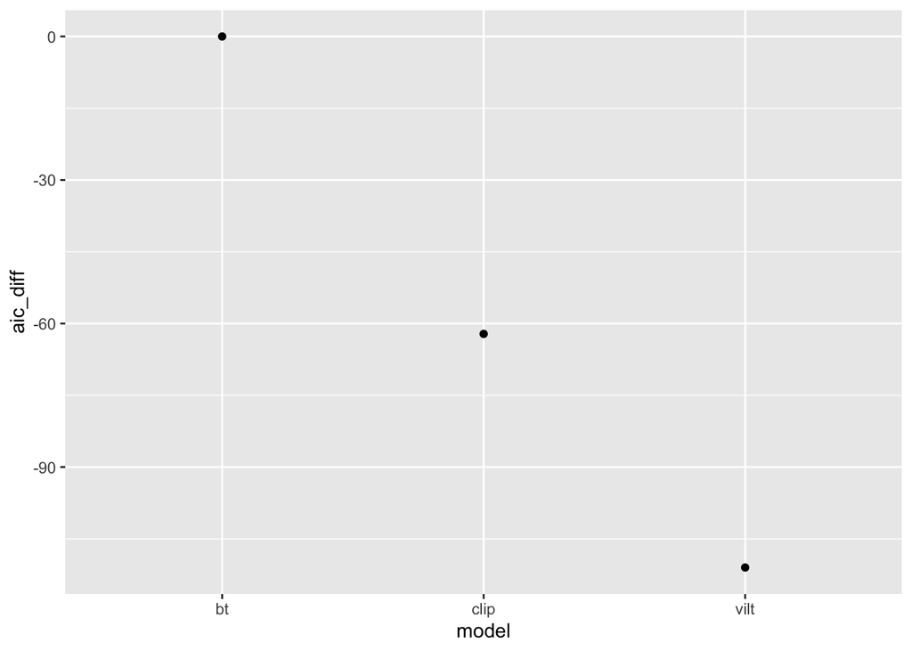

```r
h7b.agg <- data.frame(model=c("clip", "bt", "vilt"),
           aic=c(
             summary(h7b.clip)$AICtab,
             summary(h7b.bt)$AICtab,
             summary(h7b.vilt)$AICtab))


h7b.agg %>%
  mutate(
    aic_diff = aic - max(aic)
  ) %>%
  ggplot(aes(x = model, y = aic_diff)) +
  geom_point(stat="identity")
```

### 8.2.1 By Feature type

```r
# Initialize empty data frame to store summarized results
h7b.summary <- data.frame()

# Loop through each unique combination of model and dataset
for (dataset_name in unique(h7.human_data$dataset)) {
  for (model_name in unique(h7.human_data$model)) {

    # Subset the data
    subset_data <- h7.human_data %>%
      filter(dataset == dataset_name, model==model_name)


    # Run linear model
    result <- summary(lmer(rt ~ similarity + (1 | quadruplet_id),
                           data = subset_data))

    # Store the summarized t-test result in the data frame
    h7b.summary <- rbind(h7b.summary, data.frame(
      dataset = dataset_name,
      model = model_name,
      estimate = result$coefficients[2,1],
      df = result$coefficients[2,3],
      t_value = result$coefficients[2,4],
      p_value = result$coefficients[2,5],
      AIC = result$AICtab
    ))
  }
}

# View the summarized results
h7b.summary <- h7b.summary %>%
  mutate(
    dataset = factor(dataset, levels=c("Shape", "Color", "Orientation", "Size", "Volume"))
  )

h7b.summary
```

```
##           dataset       model    estimate        df     t_value      p_value
## REML  Orientation bridgetower   -5.818196 7455.9571  -0.3181758 7.503605e-01
## REML1 Orientation        vilt  -15.797566 7449.2073  -1.0186126 3.084200e-01
## REML2 Orientation    ViT-B-32  -25.911868 7450.7307  -1.5511800 1.209010e-01
## REML3       Shape bridgetower  -80.011700 8384.2994  -4.5877697 4.545132e-06
## REML4       Shape        vilt -169.343444 8385.3872 -12.8948499 1.096224e-37
## REML5       Shape    ViT-B-32 -129.852580 8384.9897  -9.5319764 1.980934e-21
## REML6        Size bridgetower  -38.943659  335.0360  -0.6529334 5.142470e-01
## REML7        Size        vilt  -16.809339  335.0218  -0.4596341 6.460770e-01
## REML8        Size    ViT-B-32   76.943269  336.1789   1.4820870 1.392539e-01
##              AIC
## REML  112600.220
## REML1 112599.614
## REML2 112598.099
## REML3 128506.144
## REML4 128363.078
## REML5 128437.283
## REML6   4950.230
## REML7   4951.424
## REML8   4948.740
```